# COVID-19 Worldwide: Trends, Demographics, and Economic Context

Samuel Amuzu and Nick Schaufelberger

2025-09-18

## Introduction and motivation

We decided to look into a publicly available COVID-19 [**dataset**](https://www.kaggle.com/datasets/assemelqirsh/covid19-dataset/data) sourced from Kaggle. It contains daily records of confirmed cases, deaths, and other related variables across multiple countries and regions. We will be analyzing the worldwide impact of COVID-19 by merging pandemic case data with demographic and economic indicators in a later stage of the report, sourced [**here**](https://www.kaggle.com/datasets/tanishksharma9905/global-economic-indicators-20102025) from the World Bank Open Data. We explore how population size and GDP per capita influence the spread and severity of COVID-19 and visualize temporal and geographic trends.

The choice of datasets was motivated by the authors’ backgrounds: one of us worked in a COVID-19 laboratory and was curious to investigate the pandemic’s global health impact, while the other has an economics background and was more interested in its economic consequences. Merging these datasets allowed us to explore both dimensions together, enabling a richer understanding of how health and economic factors interacted or were affected during the pandemic years (2020–2024).

## Objectives and hypotheses

The main objective of our analysis is to investigate how the COVID-19 pandemic evolved across different regions of the world and how everything interacted with specific socio-economic indicators. By combining epidemiological data with economic data, we aim to capture both the direct health effects and the wider economic consequences of the pandemic.

Our specific objectives are to describe how COVID-19 cases, deaths, and vaccinations progressed across continents over time, to compare socio-economic trends such as unemployment and GDP development during the same period, and to explore potential relationships between the severity of the pandemic and the socio-economic resilience of continents and countries.

**From these objectives, we formulate the following hypotheses:**

> Countries with higher GDP per capita experienced lower relative case fatality rates, reflecting stronger healthcare systems

> Unemployment rates increased during the pandemic, particularly in regions with stricter lockdowns

> Higher vaccination rate is positively associated with economic recovery, as reflected in lower unemployment and higher GDP growth

> Regional differences in pandemic waves will align with differences in socio-economic resilience

These general hypotheses will provide the framework and guidance for our data preparation, visualization, and statistical analysis in the following sections.

## Preparing and cleaning the COVID-19 data

```r
#Load Libraries
library(tidyr)
library(dplyr)
library(ggplot2)
library(patchwork)
library(readr)
library(readxl)
library(lubridate)
library(reshape2)
library(rnaturalearth)
library(sf)
library(tidyverse)
library(cartogram)
library(ggforce)
library(countrycode)
library(scales)
library(plotly)
```

We used COVID-19 related data as our main dataset. To begin the project, we started by loading the raw COVID-19 dataset into R. Before performing any analysis it was important to explore the data by checking the first few rows, the structure of the data and the column names. This helped us understand what kind of information was included in the dataset and in what format.

```r
#Load the COVID-19 dataset
covid_data <- read.csv(
  "data/covid_data.csv"
)

#Exploring the data
head(covid_data, n = 20)
str(covid_data)
colnames(covid_data)
```

Next, we focused only on the features relevant to our research question, such as *total cases*, *total deaths*, *reproduction rate*, *new cases*, and *vaccination data*, as well as socio-economic indicators like *population* and the *Human Development Index*. Reducing the number of features in this way made the dataset easier to handle and ensured that our analysis remained closely aligned with our research question.

While inspecting the structure of the selected dataset, we noticed that some variables were not stored in the most suitable data types. For example, the date column was stored as plain text (character), which would have prevented us from performing time-series analysis. We therefore converted it to the Date type. Similarly, the continent and location columns were stored as characters, but since they represent categories, we converted them into factors to allow for more meaningful group comparisons.

Finally, we reformatted the date into the standard format (YYYY-MM-DD) to ensure consistency and arranged the dataset so that observations for each country were ordered chronologically, making it more convenient for time-series analysis.

```r
#Select only the variables needed for analysis
covid.data.selected <- covid_data %>%
  select(
    continent,
    location,
    date,
    total_cases,
    total_deaths,
    reproduction_rate,
    people_fully_vaccinated,
    positive_rate,
    total_tests,
    new_cases,
    population,
    human_development_index
  )

#Inspect the reduced data set to confirm selection
covid.data.selected
str(covid.data.selected)

#Convert continent and location to factors, and date to Date type
covid.data.selected <- covid.data.selected %>%
  mutate(across(c(continent, location), as.factor), date = as.Date(date))

#Change the format of the date and order rows by location and date
covid.data.selected <- covid.data.selected %>%
  mutate(date = as.Date(date, format = "%Y-%m-%d")) %>%
  arrange(location, date)

#Check the structure again to confirm transformation
str(covid.data.selected)
covid.data.selected
```

After, we created a new year column to extract the year from the full date column because it aligns with our research on making comparison across 2020 to 2024 and it reduces day-to-day noise which we believe is not required for continent level trends Before aggregating our data, we recorded the row counts and removed any duplicates that were identical across all columns and then noted how many were dropped. Next, we had a look at the continent variable, which we noticed contained an empty string. These empty values indicated missing continent information. We removed these rows, as observations without continent data will not contribute meaningfully to continent-level analysis. We also addressed missing values more broadly, empty rows were converted to NA values so that they can be handled consistently at later stages. Rows that were completely empty across all columns were removed since they carried no useful information and finally, infinite values were replaced with NA to avoid errors during statistical analysis and visualisation. At this point the data was cleaned and ready for further analysis.

```r
#Converting date to year
covid.data.selected <- covid.data.selected %>%
  mutate(year = year(date)) %>%
  select(-date)

#Count and remove duplicates across all columns
#Count number of rows
n_before <- nrow(covid.data.selected)

#Remove only rows that are identical across all columns
covid.data.selected <- covid.data.selected %>%
  distinct(.keep_all = TRUE)

#Count rows again after removing duplicates
n_after <- nrow(covid.data.selected)

#Print result of how much data set was cleaned
n_removed <- n_before - n_after
print(paste("Removed", n_removed, "exact duplicates"))

dim(covid.data.selected)


#Empty string included in the continent levels
levels(covid.data.selected$continent)
nlevels(covid.data.selected$continent)
unique(covid.data.selected$continent)
table(covid.data.selected$continent)

#Observations in empty string level
empty_string <- covid.data.selected %>%
  filter(continent == "") %>%
  distinct(location)

empty_string

#Remove observations with empty strings
covid.data.selected <- covid.data.selected %>%
  filter(continent != "") %>%
  mutate(continent = droplevels(continent))

nlevels(covid.data.selected$continent)
levels(covid.data.selected$continent)

#Missing values - turning empty string into NA
covid.data.selected <- covid.data.selected %>%
  mutate(across(where(is.character), ~ na_if(., "")))

#Drop rows missing entries in multiple features
covid.data.selected <- covid.data.selected %>%
  filter(!if_all(everything(), is.na))

dim(covid.data.selected)
covid.data.selected

#Convert rows containing -Inf to NA
covid.data.selected <- covid.data.selected %>%
  mutate(across(where(is.numeric), ~ ifelse(is.infinite(.) &
                                              . < 0, NA, .)))

covid.data.selected
```

## COVID-19 data analysis

We then created continent-year summaries to track the evolution of the pandemic on the continent level:

1. For the cumulative variables like total cases, total deaths, total tests and people fully vaccinated, we computed the sums to show the overall effect within each continent for each year.
2. For rates that are different within each year and are more sensitive to outliers, we used the median to provide a more robust central tendency.

### Total COVID-19 cases and deaths over years

We decided to generate two line charts (cases and deaths) showing the change over time for each continent. Log scale on the y-axis allows us to compare the continents with very different magnitudes without the largest regions dominating the view. Using both lines and points help convey both the trend across the years and their specific annual values.

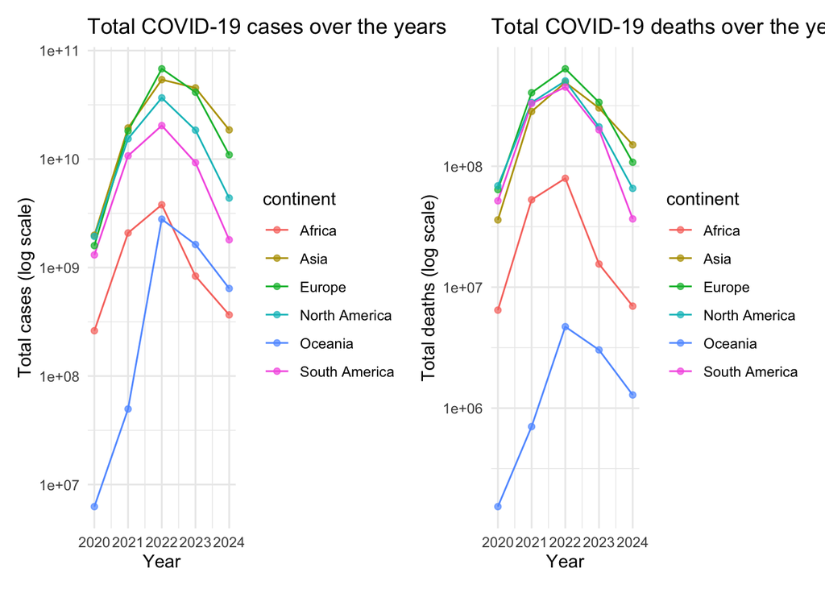

```r
# Aggregate variables yearly at the continent level
covid_continent_year <- covid.data.selected %>%
  group_by(continent, year) %>%
  summarise(
    total_cases  = sum(total_cases, na.rm = TRUE),
    total_deaths = sum(total_deaths, na.rm = TRUE),
    positive_rate = median(positive_rate, na.rm = TRUE),
    people_fully_vaccinated = sum(people_fully_vaccinated, na.rm = TRUE),
    reproduction_rate = median(reproduction_rate, na.rm = TRUE),
    total_tests = sum(total_tests),
    new_cases = sum(new_cases),
    population = sum(population)
  ) %>%
  ungroup()

#Visualize the number of cases across the years per continent
fig1 <- ggplot(covid_continent_year,
               aes(x = year, y = total_cases, colour = continent)) +
  geom_line() +
  geom_point(alpha = 0.7) +
  scale_y_log10() +
  labs(title = "Total COVID-19 cases over the years", x = "Year",
       y = "Total cases (log scale)") +
  theme_minimal()

#Visualize the number of deaths across the years per continent
fig2 <- ggplot(covid_continent_year,
               aes(x = year, y = total_deaths, colour = continent)) +
  geom_line() +
  geom_point(alpha = 0.7) +
  scale_y_log10() +
  labs(title = "Total COVID-19 deaths over the years", x = "Year",
       y = "Total deaths (log scale)") +
  theme_minimal()

#Produce both Visualisations as One
fig1 + fig2
```

### People fully vaccinated

Since vaccination was a central factor in shaping the course of the pandemic, we wanted to visualize the total number of people fully vaccinated across continents from 2020 to 2024.

To do this, we decided to create a line plot of vaccination totals over time for each continent represented by different colors. We applied a logarithmic scale on the y-axis, which helps bring very large and very small values onto the same scale and allows for easier comparisons between continents with very different population sizes. Additionally, we used faceting by continent so that each region’s vaccination trend could be inspected individually to avoid overlapping. This choice provides a clearer picture of how vaccination uptake evolved in Africa, Europe, Asia, North America and South America, highlighting both differences in scale and differences in timing.

This visualization sets the stage for comparing vaccination progress against other pandemic indicators or socio-economic indicators after merging to world indicator data like GDP, unemployment, and inflation. By doing so, we aim to uncover whether regions with stronger economic indicators were able to vaccinate their populations more rapidly and effectively.

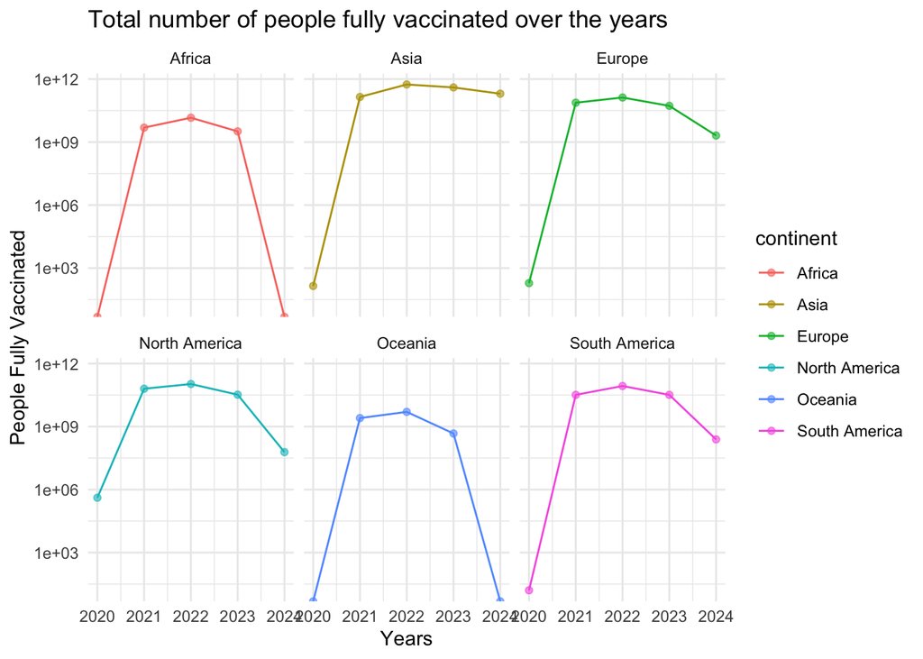

```r
#Visualisation for Total people Vaccinated by Each Continent over the Years
ggplot(covid_continent_year,
       aes(x = year, y = people_fully_vaccinated, colour = continent)) +
  geom_line() +
  geom_point(alpha = 0.6) +
  scale_y_log10() +
  facet_wrap( ~ continent) +
  labs(title = "Total number of people fully vaccinated over the years",
       x = "Years",
       y = "People Fully Vaccinated") +
  theme_minimal()
```

The line plots show that vaccination rollouts followed different trajectories across continents between 2020 and 2024. Asia and Europe reached the highest absolute numbers of fully vaccinated people early on, reflecting large-scale campaigns and relatively strong logistical capacity. North and South America also achieved substantial vaccination coverage, though with slightly more fluctuation over time. In contrast, Africa and Oceania show much smaller totals, indicating slower or more limited vaccine access relative to population size. Overall, the visualization highlights striking inequalities in global vaccination progress. Regions with stronger healthcare systems and greater economic resources were able to vaccinate large shares of their populations quickly, while other continents lagged behind.

### Case Fatality Rate (CFR)

After preparing continent–year aggregates, we calculated the case fatality rate (CFR) for each continent between 2020 and 2024. The CFR is defined as the ratio of total deaths to total confirmed cases, multiplied by 100 to express it as a percentage. Case Fatality Rate is a measure used to identify the risk of dying from a disease

To visualize CFR, we used a heatmap with years along the x-axis and continents on the y-axis. The color of each tile represents the CFR for that continent-year combination. This design makes it easy to compare values both across time on how CFR changed between 2020 and 2024 and across the differences between continents. We chose the viridis colour palette for the fill scale because it is colourblind-friendly and offers a smooth gradient, making small differences in CFR easier to see.

This heatmap provides a compact overview of the data: for example, we can quickly spot whether CFR was highest in the early phase of the pandemic, whether it declined after the introduction of vaccines, and which continents experienced consistently higher fatality rates compared to others.

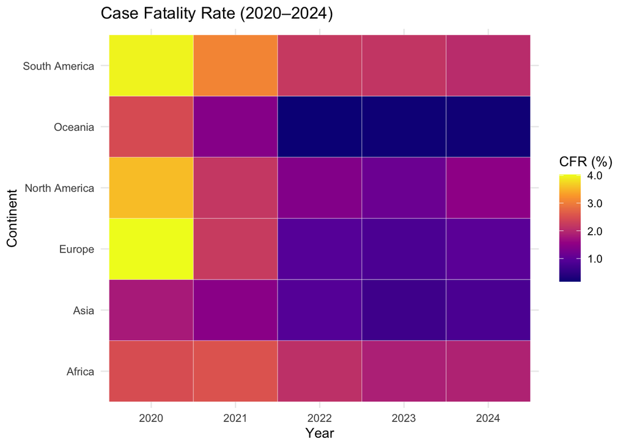

```r
#Calculating Case Fatality Rate at continent-year level
#CFR = (total deaths / total cases) * 100
covid_CFR <- covid_CFR <- covid_continent_year %>%
  mutate(cfr = 100 * total_deaths / total_cases) %>%
  select(continent, year, cfr)

#Inspect the data
covid_CFR

#Visualize CFR over time per continent with heatmap
ggplot(covid_CFR, aes(x = factor(year), y = continent, fill = cfr)) +
  geom_tile(color = "white") +
  #use vridis color palette
  #format legend labels to 1 decimal place
  scale_fill_viridis_c(option = "C",
                       labels = scales::number_format(accuracy = 0.1)) +
  labs(title = "Case Fatality Rate (2020–2024)",
       x = "Year",
       y = "Continent",
       fill = "CFR (%)") +
  theme_minimal()
```

## Preparing and cleaning the World Bank data

We first imported the World Bank dataset and inspected it using functions such as head(), str(), summarise(), and colnames() to better understand its structure and variable names. We then selected only the variables relevant to our analysis: country name, year, inflation rate, GDP per capita, unemployment rate, and GDP annual growth. To make the dataset easier to work with, we renamed the columns to shorter and consistent labels (location, year, inflation_rate, GDP, unemployment_rate, gdp_annual_growth).

Next, we converted the data types for our analysis: the location variable was transformed into a factor to be able to perform analysis across countries, while year was explicitly converted into numeric format. Finally, we re-checked the structure of the dataset to ensure proper formatting and consistency. These steps allowed us to create a clean and well-structured dataset.

```r
#Read world bank data
world.indicator <- read_csv("data/world_bank_data_2025.csv")

head(world.indicator)
str(world.indicator)
summarise(world.indicator)
colnames(world.indicator)

#Select specific columns of interest
world.indicator.selected <- world.indicator %>%
  select(
    country_name,
    year,
    `Inflation (CPI %)`,
    `GDP per Capita (Current USD)`,
    `Unemployment Rate (%)`,
    `GDP Growth (% Annual)`
  )

#Changing column names
colnames(world.indicator.selected) <- c(
  "location",
  "year",
  "inflation_rate",
  "GDP",
  "unemployment_rate",
  "gdp_annual_growth"
)

#Converting data types for analysis
world.indicator.selected
world.indicator.selected$location <- as.factor(world.indicator.selected$location)
world.indicator.selected$year <- as.numeric(world.indicator.selected$year)

str(world.indicator.selected)
world.indicator.selected

levels(world.indicator.selected$location)
min(world.indicator.selected$year)
max(world.indicator.selected$year)
```

## World Bank data analysis

In line with the approach taken for the COVID-19 dataset, we also examined the second dataset sourced from the World Bank, which contains key socio-economic indicators. Our goal was to understand the broader context in which the pandemic unfolded by linking health outcomes with economic and social conditions. We began by exploring the structure of the dataset and identifying countries with the highest unemployment rates, the highest GDP per capita, and the highest inflation rates. This provided an initial overview of global socio-economic disparities and allowed us to compare different regions more systematically. Focusing on these attributes was important because they can directly or indirectly influence how countries experienced and responded to the pandemic. For instance, high unemployment or inflation can strain healthcare systems and public resources, while higher GDP per capita often correlates with stronger infrastructure and resilience. We had to explore this data on a country level instead of continent level because the continents were not included in this dataset so we could only analyse on continent level after merging

### Top 10 countries with the highest GDP

Analyzing the countries with the highest GDP per capita is important in the context of our project because GDP per capita serves as a proxy for a country’s wealth and resources. Higher income levels often correlate with better healthcare infrastructure, stronger social systems, and more fiscal capacity to respond to crisis like the COVID-19 pandemic. This helps us understand why wealthier countries may have had more resilience and different outcomes compared to countries with limited economic resources.

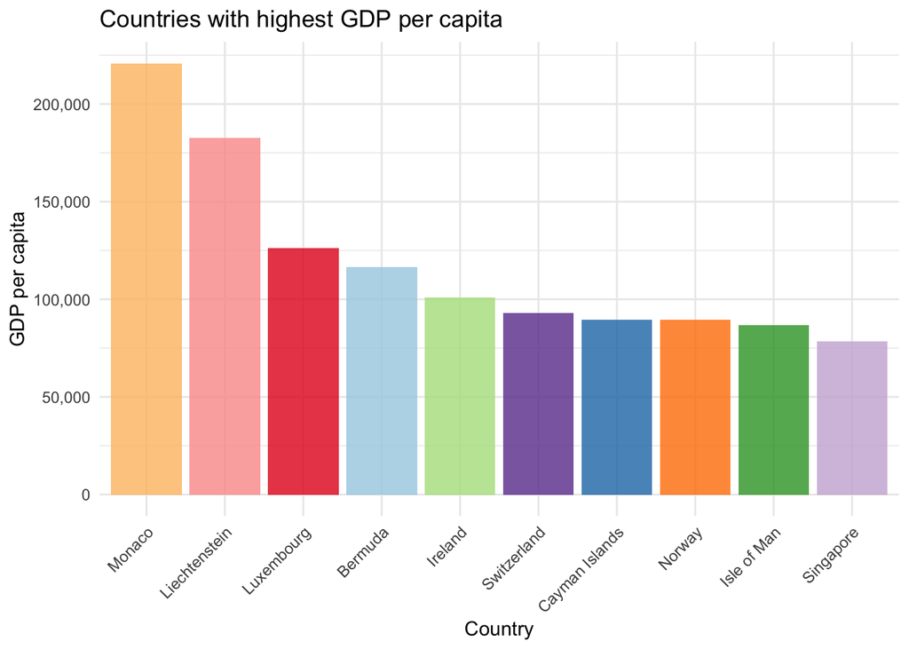

```r
#Top 10 countries with the Highest GDP per capita (2020–2024)
top10_gdp <- world.indicator.selected %>%
  filter(year >= 2020, year <= 2024) %>%
  group_by(location) %>%
  summarise(mean_gdp = mean(GDP, na.rm = TRUE), .groups = "drop") %>%
  arrange(desc(mean_gdp)) %>%
  slice_head(n = 10)

#Visualisation of top 10 countries with the Highest GDP per capita (2020- 2024)
ggplot(top10_gdp, aes(
  x = reorder(location, -mean_gdp),
  y = mean_gdp,
  fill = location
)) +
  geom_col(alpha = 0.8) +
  scale_fill_brewer(palette = "Paired") +
  labs(title = "Countries with highest GDP per capita", x = "Country",
       y = "GDP per capita") +
  scale_y_continuous(labels = comma) +
  theme_minimal() +
  theme(axis.text.x = element_text(angle = 45, hjust = 1),
        legend.position = "none")
```

Monaco leads by a large margin, followed by Liechtenstein and Luxembourg, all with values far above USD 100’000 per person. Other high-income countries and territories such as Bermuda, Ireland, Switzerland also appear in the top ten, with GDP per capita values ranging between roughly USD 80’000 and USD 120’000. These Top 10 countries are mostly small states or financial hubs with specialized economies and strong global integration.

### Top 10 countries with the highest inflation rate

Furthermore, we decided to examine the countries with the highest inflation rates is relevant because inflation directly affects the affordability of goods, healthcare, and essential services. Extreme inflation undermines economic stability, erodes public trust, and limits government capacity to respond effectively to crisis like the COVID-19 pandemic. In this way, inflation serves as a critical indicator of socio-economic vulnerability, helping us understand how economic instability may have amplified the pandemic’s effects in different regions.

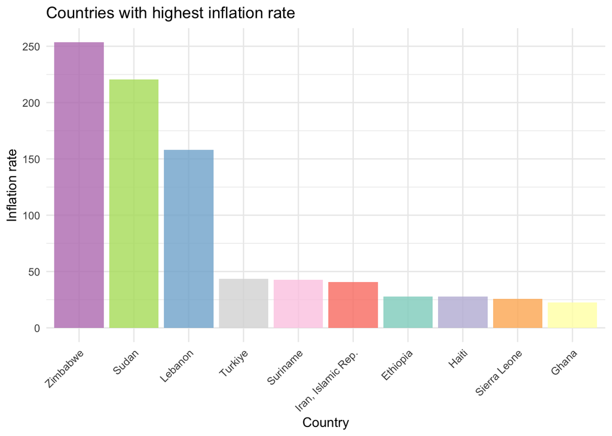

```r
#Top 10 countries with highest inflation rate (2020–2024)
top10_inflation <- world.indicator.selected %>%
  filter(year >= 2020, year <= 2024) %>%
  group_by(location) %>%
  summarise(mean_inflation = mean(inflation_rate, na.rm = TRUE),
            .groups = "drop") %>%
  arrange(desc(mean_inflation)) %>%
  slice_head(n = 10)

#Visualisation of Top 10 countries with Highest Inflation rate (2020-2024)
ggplot(top10_inflation,
       aes(
         x = reorder(location, -mean_inflation),
         y = mean_inflation,
         fill = location
       )) +
  geom_col(alpha = 0.8) +
  scale_fill_brewer(palette = "Set3") +
  labs(title = "Countries with highest inflation rate", x = "Country",
       y = "Inflation rate") +
  scale_y_continuous(labels = comma) +
  theme_minimal() +
  theme(axis.text.x = element_text(angle = 45, hjust = 1),
        legend.position = "none")
```

### Top 10 countries with highest unemployment rate

Analyzing the countries with the highest unemployment rates is also relevant for our project because unemployment reflects the economic vulnerability of a population and its capacity to cope with external shocks, such as the COVID-19 pandemic. High unemployment may strain healthcare systems, reduce public trust, and limit governments’ ability to enforce or support effective pandemic measures. This provides important socio-economic context when linking pandemic outcomes with underlying structural conditions.

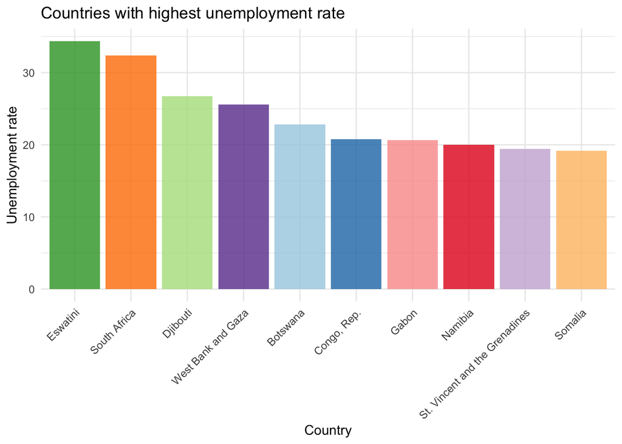

```r
#Top 10 by unemployment (2020–2024)
top10_unemployment <- world.indicator.selected %>%
  filter(year >= 2020, year <= 2024) %>%
  group_by(location) %>%
  summarise(mean_unemployment = mean(unemployment_rate, na.rm = TRUE),
            .groups = "drop") %>%
  arrange(desc(mean_unemployment)) %>%
  slice_head(n = 10)

#Visualisation top 10 countries with the Highest Unemployment rate
ggplot(top10_unemployment,
       aes(
         x = reorder(location, -mean_unemployment),
         y = mean_unemployment,
         fill = location
       )) +
  geom_col(alpha = 0.8) +
  scale_fill_brewer(palette = "Paired") +
  labs(title = "Countries with highest unemployment rate", x = "Country",
       y = "Unemployment rate") +
  scale_y_continuous(labels = comma) +
  theme_minimal() +
  theme(axis.text.x = element_text(angle = 45, hjust = 1),
        legend.position = "none")
```

Eswatini and South Africa stand out with unemployment rates exceeding 30%, followed by Djibouti and the West Bank and Gaza with values between 25% and 30%. The other countries in the top ten, such as Botswana, Congo Rep., Gabon, Namibia, St. Vincent and the Grenadines and Somalia, range between 20% and 25%. Most of these countries are located in Africa, which underlines the regional dimension of per continent unemployment challenges.

### World Map of average GDP per capita from 2020-2024

We decided to explore the average GDP on a global economic landscape using a map graph. We calculated the average GDP per capita for each country between 2020 and 2024. The data was first cleaned by converting country names into ISO-3 codes and then aggregated at the country level to compute the mean GDP across these years. This ensured that short-term fluctuations did not dominate the analysis, providing us with a smoother picture of economic conditions over time.

Next, the GDP data was merged with country polygons from Natural Earth to create a spatial dataset, which allowed us to visualise the results on a world map. Because GDP per capita values are highly skewed—ranging from very low incomes in some African and Asian countries to very high incomes in parts of Europe, North America, and Oceania. We applied a logarithmic colour scale to make the differences across the globe easier to compare, as without transformation most countries would appear too similar.

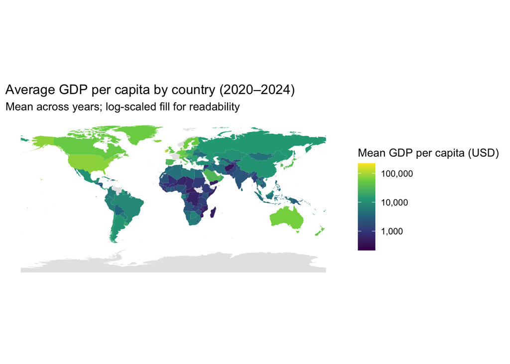

```r
#Visualisation of GDP per capita on map
gdp_clean <- world.indicator.selected %>%
  filter(year >= 2020, year <= 2024) %>%
  #Convert country names to ISO-3 codes
  mutate(iso_a3 = countrycode(location, "country.name", "iso3c")) %>%

  #Group by country and calculate mean GDP across 2020 to 2024
  group_by(iso_a3) %>%
  summarise(mean_gdp = mean(GDP, na.rm = TRUE), .groups = "drop") %>%

  #Drop invalid rows
  filter(!is.na(iso_a3), is.finite(mean_gdp))

#Load country polygons from Natural Earth (sf object)
world <- ne_countries(scale = "medium", returnclass = "sf") %>%
  mutate(iso_a3 = iso_a3)  # keep name consistent

#Join data with world map
map_df <- world %>%
  left_join(gdp_clean, by = "iso_a3")

#Chloropleth map of GDP
ggplot(map_df, aes(fill = mean_gdp)) +
  geom_sf(color = NA) +

  #Color scale: viridis with log10 transformation for skewed GDP
  scale_fill_viridis_c(
    trans = "log10",
    labels = comma,
    na.value = "grey90",
    #colour for missing data
    name = "Mean GDP per capita (USD)"
  ) +
  labs(
    title = "Average GDP per capita by country (2020–2024)",
    subtitle = "Mean across years; log-scaled fill for readability",
    x = NULL,
    y = NULL
  ) +

  #Minimal theme
  theme_minimal() +
  theme(panel.grid = element_blank())
```

The world map of average GDP per capita (2020–2024) complements the bar chart of the top ten countries with the highest GDP per capita. While the bar chart highlights a handful of very wealthy small states and financial hubs such as Monaco, Liechtenstein, and Luxembourg, the map provides a broader perspective by revealing how these extreme values compare to global patterns. It shows clear clusters of wealth in North America, Western Europe, and parts of East Asia, contrasting sharply with much lower GDP per capita levels across Sub-Saharan Africa.

When viewed alongside the unemployment bar chart above, the map also helps explain why high unemployment rates are concentrated in African countries despite their relatively low GDP per capita. This underscores the disparities between regions with strong economic resources and those struggling with weaker labor markets. However, further analysis may be required to completely conclude on these statements.

### Unemployment rate vs. GDP

```r
#Number of NAs in world.indicator.selected
colSums(is.na(world.indicator.selected))
```

```
##          location              year    inflation_rate               GDP
##                 0                 0               778               534
## unemployment_rate gdp_annual_growth
##               677               560
```

```r
#Preparation for linear regression model
linear.regression <- world.indicator.selected %>%
  select(GDP, unemployment_rate) %>%
  drop_na()

#Linear Regression
model <- lm(unemployment_rate ~ GDP, data = linear.regression)
summary(model)
```

```
##
## Call:
## lm(formula = unemployment_rate ~ GDP, data = linear.regression)
##
## Residuals:
##    Min     1Q Median     3Q    Max
## -8.364 -4.305 -1.389  2.831 26.942
##
## Coefficients:
##               Estimate Std. Error t value Pr(>|t|)
## (Intercept)  8.573e+00  1.461e-01   58.70  < 2e-16 ***
## GDP         -4.050e-05  5.586e-06   -7.25 5.48e-13 ***
## ---
## Signif. codes:  0 '***' 0.001 '**' 0.01 '*' 0.05 '.' 0.1 ' ' 1
##
## Residual standard error: 5.959 on 2557 degrees of freedom
## Multiple R-squared:  0.02014,    Adjusted R-squared:  0.01976
## F-statistic: 52.57 on 1 and 2557 DF,  p-value: 5.478e-13
```

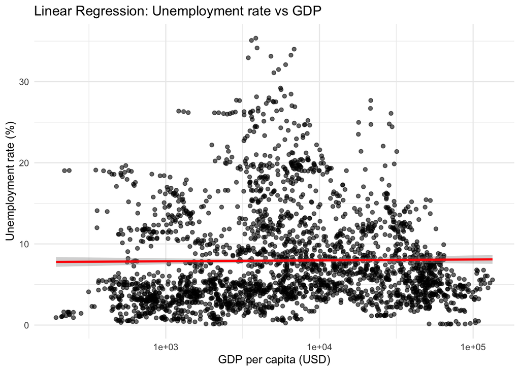

```r
#Visualisation of Linear Regression
ggplot(linear.regression, aes(x = GDP, y = unemployment_rate)) +
  geom_point(alpha = 0.6) +
  geom_smooth(method = "lm",
              se = TRUE,
              colour = "red") +
  scale_x_log10() +   # GDP skewed
  labs(title = "Linear Regression: Unemployment rate vs GDP",
       x = "GDP per capita (USD)", y = "Unemployment rate (%)") +
  theme_minimal()
```

```r
cor(linear.regression$GDP, linear.regression$unemployment_rate)
```

```
## [1] -0.1419318
```

The model shows a *statistically significant* negative relationship **(p < 0.001)**, meaning countries with higher GDP per capita tend to have slightly lower unemployment rates. However, the *effect size* is very small **(R² = 0.02, correlation = –0.14)**, indicating that GDP alone explains little of the variation. This suggests that while wealthier countries often have stronger labor markets, many other factors beyond GDP influence unemployment as well.

## Merging two datasets

To better understand the impact of COVID-19 across countries, we decided to combine the COVID-19 dataset with the additional socio-economic data such as inflation rate, GDP, unemployment rate and annual growth of GDP. By merging and extending it with these economic indicators, we can explore possible relationships between the spread of the virus and the economic strength of a country.

We merged the two datasets using an inner join on both location and year. This approach was chosen because it only keeps rows that exist in both datasets, guaranteeing that each record in the merged dataset contains both epidemiological outcomes and socioeconomic indicators for the same country and year.

To validate the merge, we checked the minimum and maximum years in the resulting dataset. This confirmed that the dataset now spans the correct research window from 2020 to 2024.

Finally, we assessed the data completeness by calculating the number of missing values in each column. This step is crucial for us to perform statistical analysis or modelling, as it highlights where further cleaning may be needed.

```r
#Filter world bank indicator to match research window (2020 - 2024)
#Grouping by location and year to align with Covid Data during merge
world.indicator.selected <- world.indicator.selected %>%
  group_by(location, year) %>%
  filter(year >= 2020 & year <= 2024)

#Performed inner join containing records with location and year in both datasets
merged.data <- inner_join(covid.data.selected,
                          world.indicator.selected,
                          by = c("location", "year"))

#Inspect merged data
merged.data

#Verify time coverage following merge
min(merged.data$year)
max(merged.data$year)

dim(merged.data)

#Count missing values in each column
colSums(is.na(merged.data))
```

### Correlation heatmap: COVID-19 vs. Socio-economic indicators

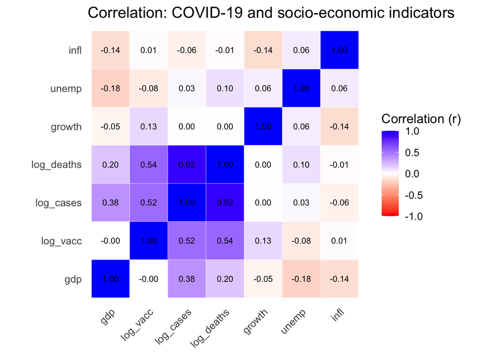

```r
#Perform country-year level analysis
#Construct specific summary statistics for visualisation
df_corr <- merged.data %>%
  group_by(location, year) %>%
  summarise(
    cases   = max(total_cases, na.rm = TRUE),
    deaths  = max(total_deaths, na.rm = TRUE),
    vacc    = max(people_fully_vaccinated, na.rm = TRUE),
    gdp     = mean(GDP, na.rm = TRUE),
    unemp   = mean(unemployment_rate, na.rm = TRUE),
    infl    = mean(inflation_rate, na.rm = TRUE),
    growth  = mean(gdp_annual_growth, na.rm = TRUE),
    .groups = "drop"
  ) %>%
  mutate(
    # log transform highly skewed totals
    log_cases  = log1p(cases),
    log_deaths = log1p(deaths),
    log_vacc   = log1p(vacc)
  )

#Keep only numerical variables for correlation
num_vars <- df_corr %>%
  select(log_cases, log_deaths, log_vacc, gdp, unemp, infl, growth) %>%
  drop_na()

#Correlation matrix Analysis
corr_mat <- cor(num_vars, use = "pairwise.complete.obs")
ord <- hclust(dist(corr_mat))$order
corr_long <- reshape2::melt(corr_mat[ord, ord], value.name = "r")

#Heatmap with annotated r values and a symmetric diverging scale
ggplot(corr_long, aes(Var1, Var2, fill = r)) +
  geom_tile(color = "white") +
  geom_text(aes(label = sprintf("%.2f", r)), size = 3) +
  scale_fill_gradient2(
    low = "red",
    mid = "white",
    high = "blue",
    midpoint = 0,
    limits = c(-1, 1),
    name = "Correlation (r)"
  ) +
  coord_fixed() +
  theme_minimal(base_size = 13) +
  theme(axis.text.x = element_text(
    angle = 45,
    vjust = 1,
    hjust = 1
  ),
  panel.grid = element_blank()) +
  labs(title = "Correlation: COVID-19 and socio-economic indicators", x = NULL,
       y = NULL)
```

The results reveal that COVID-19 *cases*, *deaths*, and *vaccination rates* are **strongly positively correlated**, which is expected since higher case numbers often led to more deaths and greater vaccine rollouts. In contrast, socio-economic indicators such as *GDP*, *unemployment*, *inflation*, and *growth* show only **weak correlations** with COVID-19 variables, suggesting that pandemic outcomes were not strongly determined by these factors alone.